# Snake tracking

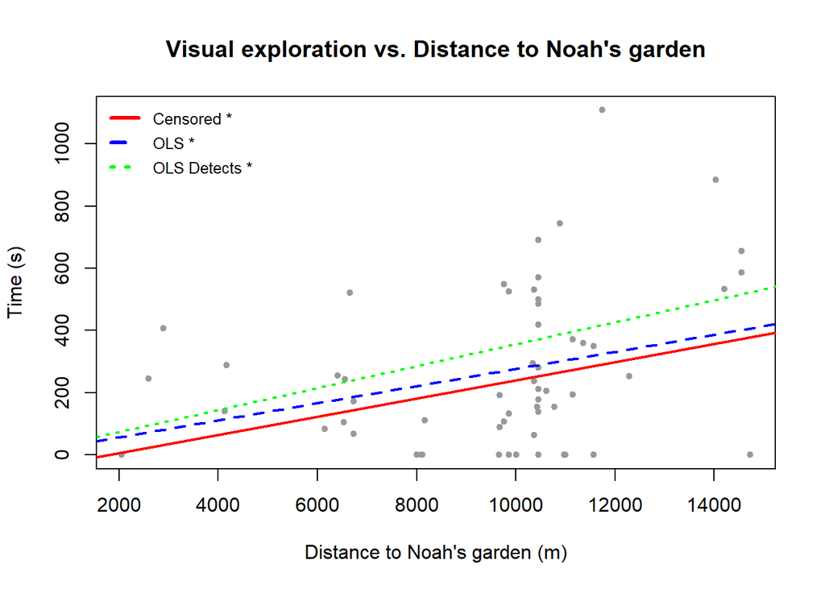

```r
# Plot the results
lineplot <- function() {

  # Add lines
  abline(coef(fit.cen)[1:2], col = "red", lwd = 2)
  abline(coef(fit.OLS), col = "blue", lty = 2, lwd = 2)
  abline(coef(fit.detect), col = "green", lty = 3, lwd = 2)

  # Add legend
  legend(
    "topleft",
    legend = c(
      "Censored *",
      "OLS *",
      "OLS Detects *"
    ),
    lwd = 3 * par("cex"),
    col = c("red", "blue", "green"),
    lty = c(1, 2, 3),
    text.font = 1, bty = "n",
    pt.cex = 1, cex = 0.8, y.intersp = 1.3
  )
}

plot(summary_tracking_complete_no_rep$Distance_Noahs, (summary_tracking_complete_no_rep$Visual_exp), pch = 19, cex = 0.7, col = 'grey60', main = "Visual exploration vs. Distance to Noah's garden", xlab = "Distance to Noah's garden (m)", ylab = "Time (s)")

lineplot()
```

```r
# ~ Condition
# Censored regression
fit.cen <- censReg((Visual_exp) ~ Condition, data = summary_tracking_complete_no_rep, left = 0, right = Inf)

summary(fit.cen)
```

```
Call:
censReg(formula = (Visual_exp) ~ Condition, left = 0, right = Inf,
    data = summary_tracking_complete_no_rep)

Observations:
         Total  Left-censored     Uncensored Right-censored
            58             13             45              0

Coefficients:
             Estimate Std. error t value Pr(> t)
(Intercept)  394.0729   369.0533   1.068   0.286
Condition   -164.4492   357.1482  -0.460   0.645
logSigma       5.7267     0.1111  51.557  <2e-16 ***
---
Signif. codes:  0 '***' 0.001 '**' 0.01 '*' 0.05 '.' 0.1 ' ' 1

Newton-Raphson maximisation, 7 iterations
Return code 1: gradient close to zero (gradtol)
Log-likelihood: -334.1932 on 3 Df
```

```r
# Fit a line using OLS regression (linear regression)
fit.OLS <- lm((Visual_exp) ~ Condition, data = summary_tracking_complete_no_rep)

summary(fit.OLS)
```

```
Call:
lm(formula = (Visual_exp) ~ Condition, data = summary_tracking_complete_no_rep)

Residuals:
    Min      1Q  Median      3Q     Max
-275.57 -192.58  -62.73  148.97  836.58

Coefficients:
            Estimate Std. Error t value Pr(>|t|)
(Intercept)   317.54     286.16   1.110    0.272
Condition     -50.88     275.92  -0.184    0.854

Residual standard error: 254.3 on 56 degrees of freedom
Multiple R-squared:  0.0006068, Adjusted R-squared:  -0.01724
F-statistic: 0.034 on 1 and 56 DF,  p-value: 0.8544
```

```r
# fit regression only of non-censored data
fit.detect <- lm(Visual_exp ~ Condition, data = summary_tracking_complete_no_rep_detect)

summary(fit.detect)
```

```
Call:
lm(formula = Visual_exp ~ Condition, data = summary_tracking_complete_no_rep_detect)

Residuals:
   Min     1Q Median     3Q    Max
-303.2 -167.9  -92.4  150.8  796.6

Coefficients:
            Estimate Std. Error t value Pr(>|t|)
(Intercept)    69.73     382.09   0.182    0.856
Condition     266.62     372.93   0.715    0.479

Residual standard error: 237.2 on 43 degrees of freedom
Multiple R-squared:  0.01175,   Adjusted R-squared:  -0.01124
F-statistic: 0.5111 on 1 and 43 DF,  p-value: 0.4785
```

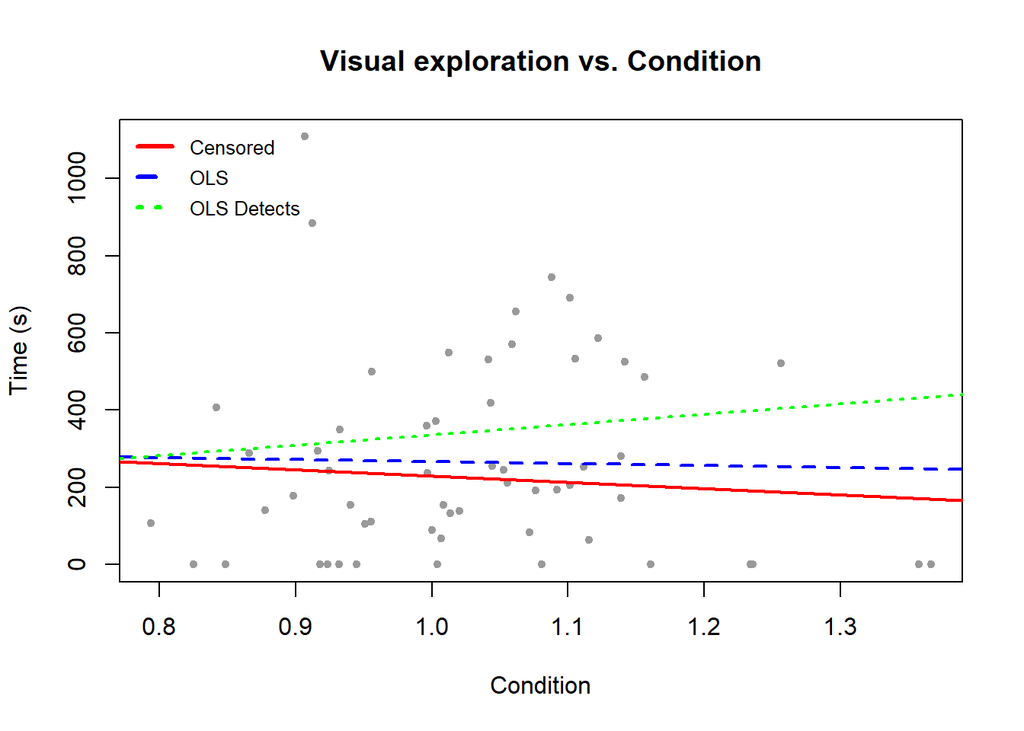

```r
# Plot the results
lineplot <- function() {

  # Add lines
  abline(coef(fit.cen)[1:2], col = "red", lwd = 2)
  abline(coef(fit.OLS), col = "blue", lty = 2, lwd = 2)
  abline(coef(fit.detect), col = "green", lty = 3, lwd = 2)

  # Add legend
  legend(
    "topleft",
    legend = c(
      "Censored",
      "OLS",
      "OLS Detects"
    ),
    lwd = 3 * par("cex"),
    col = c("red", "blue", "green"),
    lty = c(1, 2, 3),
    text.font = 1, bty = "n",
    pt.cex = 1, cex = 0.8, y.intersp = 1.3
  )
}

plot(summary_tracking_complete_no_rep$Condition, (summary_tracking_complete_no_rep$Visual_exp), pch = 19, cex = 0.7, col = 'grey60', main = "Visual exploration vs. Condition", xlab = "Condition", ylab = "Time (s)")

lineplot()
```

### 7.3.2 Log-transformation

```r
# Create log variable
summary_tracking_complete_no_rep$Visual_exp_log <- log1p(summary_tracking_complete_no_rep$Visual_exp)

# Create the same variable for the only detection data frame
summary_tracking_complete_no_rep_detect$Visual_exp_log <- log1p(summary_tracking_complete_no_rep_detect$Visual_exp)

# ~ Invasion year
# Censored regression
fit.cen <- censReg((Visual_exp_log) ~ Year_invasion, data = summary_tracking_complete_no_rep, left = 0, right = Inf)

summary(fit.cen)
```

```
Call:
censReg(formula = (Visual_exp_log) ~ Year_invasion, left = 0,
    right = Inf, data = summary_tracking_complete_no_rep)

Observations:
         Total  Left-censored     Uncensored Right-censored
            58             13             45              0

Coefficients:
               Estimate Std. error t value Pr(> t)
(Intercept)   -535.0485        Inf       0       1
Year_invasion    0.2669        Inf       0       1
logSigma         1.0955        Inf       0       1

Newton-Raphson maximisation, 5 iterations
Return code 1: gradient close to zero (gradtol)
Log-likelihood: -128.4781 on 3 Df
```

```r
# Fit a line using OLS regression (linear regression)
fit.OLS <- lm((Visual_exp_log) ~ Year_invasion, data = summary_tracking_complete_no_rep)

summary(fit.OLS)
```

```
Call:
lm(formula = (Visual_exp_log) ~ Year_invasion, data = summary_tracking_complete_no_rep)

Residuals:
    Min      1Q  Median      3Q     Max
-5.2430 -0.3235  0.9103  1.6779  2.4674

Coefficients:
               Estimate Std. Error t value Pr(>|t|)
(Intercept)   -425.9525   283.5917  -1.502    0.139
Year_invasion    0.2131     0.1404   1.517    0.135

Residual standard error: 2.411 on 56 degrees of freedom
Multiple R-squared:  0.03949,   Adjusted R-squared:  0.02234
F-statistic: 2.302 on 1 and 56 DF,  p-value: 0.1348
```

```r
# fit regression only of non-censored data
fit.detect <- lm(Visual_exp_log ~ Year_invasion, data = summary_tracking_complete_no_rep_detect)

summary(fit.detect)
```

```
Call:
lm(formula = Visual_exp_log ~ Year_invasion, data = summary_tracking_complete_no_rep_detect)

Residuals:
    Min      1Q  Median      3Q     Max
-1.6405 -0.5278  0.1455  0.5285  1.3441

Coefficients:
                Estimate Std. Error t value Pr(>|t|)
(Intercept)   -168.11211  101.53885  -1.656   0.1051
Year_invasion    0.08600    0.05027   1.711   0.0943 .
---
Signif. codes:  0 '***' 0.001 '**' 0.01 '*' 0.05 '.' 0.1 ' ' 1

Residual standard error: 0.7024 on 43 degrees of freedom
Multiple R-squared:  0.06373,   Adjusted R-squared:  0.04195
F-statistic: 2.927 on 1 and 43 DF,  p-value: 0.09432
```

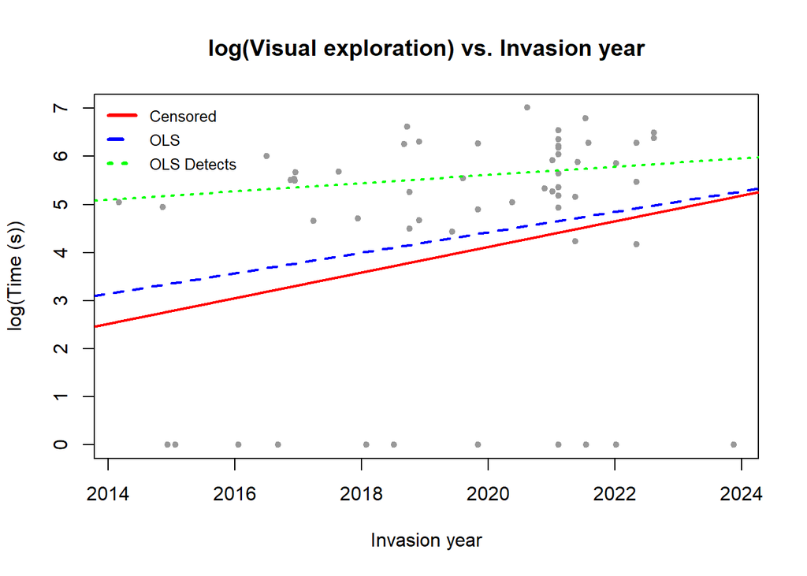

```r
# Plot the results
lineplot <- function() {

  # Add lines
  abline(coef(fit.cen)[1:2], col = "red", lwd = 2)
  abline(coef(fit.OLS), col = "blue", lty = 2, lwd = 2)
  abline(coef(fit.detect), col = "green", lty = 3, lwd = 2)

  # Add legend
  legend(
    "topleft",
    legend = c(
      "Censored",
      "OLS",
      "OLS Detects"
    ),
    lwd = 3 * par("cex"),
    col = c("red", "blue", "green"),
    lty = c(1, 2, 3),
    text.font = 1, bty = "n",
    pt.cex = 1, cex = 0.8, y.intersp = 1.3
  )
}

plot(summary_tracking_complete_no_rep$Year_invasion, (summary_tracking_complete_no_rep$Visual_exp_log), pch = 19, cex = 0.7, col = 'grey60', main = "log(Visual exploration) vs. Invasion year", xlab = "Invasion year", ylab = "log(Time (s))")

lineplot()
```

```r
# ~ Distance to Noah's garden
# Censored regression
fit.cen <- censReg((Visual_exp_log) ~ Distance_Noahs, data = summary_tracking_complete_no_rep, left = 0, right = Inf)

summary(fit.cen)
```

```
Call:
censReg(formula = (Visual_exp_log) ~ Distance_Noahs, left = 0,
    right = Inf, data = summary_tracking_complete_no_rep)

Observations:
         Total  Left-censored     Uncensored Right-censored
            58             13             45              0

Coefficients:
                Estimate Std. error t value Pr(> t)
(Intercept)    3.243e+00  1.464e+00   2.216  0.0267 *
Distance_Noahs 8.187e-05  1.466e-04   0.558  0.5765
logSigma       1.112e+00  1.141e-01   9.749  <2e-16 ***
---
Signif. codes:  0 '***' 0.001 '**' 0.01 '*' 0.05 '.' 0.1 ' ' 1

Newton-Raphson maximisation, 5 iterations
Return code 1: gradient close to zero (gradtol)
Log-likelihood: -129.4116 on 3 Df
```

```r
# Fit a line using OLS regression (linear regression)
fit.OLS <- lm((Visual_exp_log) ~ Distance_Noahs, data = summary_tracking_complete_no_rep)

summary(fit.OLS)
```

```
Call:
lm(formula = (Visual_exp_log) ~ Distance_Noahs, data = summary_tracking_complete_no_rep)

Residuals:
    Min      1Q  Median      3Q     Max
-4.7488  0.1210  0.9613  1.6904  2.4965

Coefficients:
                Estimate Std. Error t value Pr(>|t|)
(Intercept)    3.594e+00  1.155e+00   3.112  0.00292 **
Distance_Noahs 7.841e-05  1.158e-04   0.677  0.50117
---
Signif. codes:  0 '***' 0.001 '**' 0.01 '*' 0.05 '.' 0.1 ' ' 1

Residual standard error: 2.45 on 56 degrees of freedom
Multiple R-squared:  0.008119,  Adjusted R-squared:  -0.009593
F-statistic: 0.4584 on 1 and 56 DF,  p-value: 0.5012
```

```r
# fit regression only of non-censored data
fit.detect <- lm(Visual_exp_log ~ Distance_Noahs, data = summary_tracking_complete_no_rep_detect)

summary(fit.detect)
```

```
Call:
lm(formula = Visual_exp_log ~ Distance_Noahs, data = summary_tracking_complete_no_rep_detect)

Residuals:
     Min       1Q   Median       3Q      Max
-1.50353 -0.50496  0.06429  0.59334  1.19772

Coefficients:
                Estimate Std. Error t value Pr(>|t|)
(Intercept)    4.656e+00  3.576e-01  13.019  < 2e-16 ***
Distance_Noahs 9.864e-05  3.585e-05   2.752  0.00864 **
---
Signif. codes:  0 '***' 0.001 '**' 0.01 '*' 0.05 '.' 0.1 ' ' 1

Residual standard error: 0.6694 on 43 degrees of freedom
Multiple R-squared:  0.1497,    Adjusted R-squared:   0.13
F-statistic: 7.573 on 1 and 43 DF,  p-value: 0.008641
```

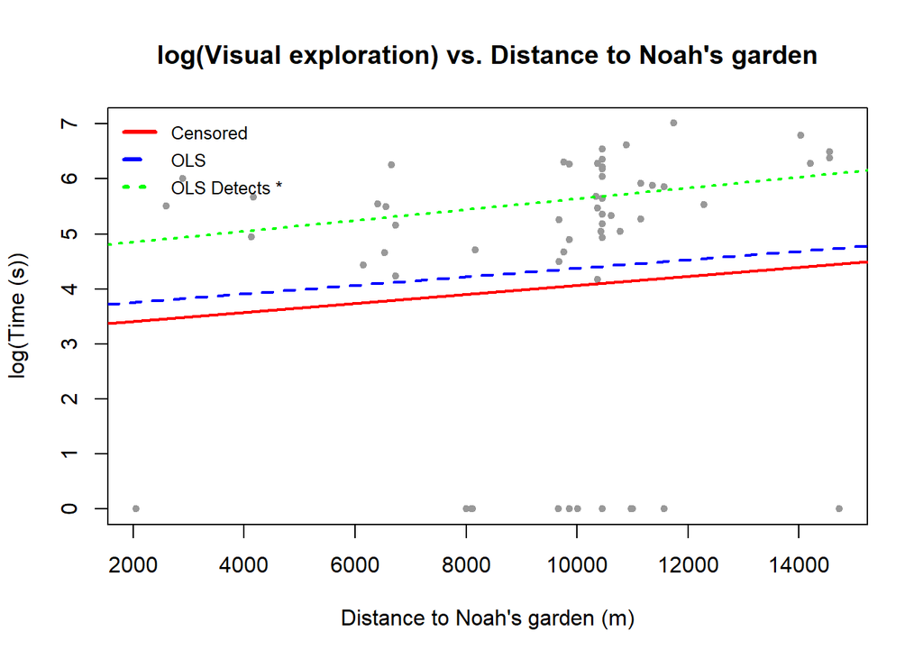

```r
# Plot the results
lineplot <- function() {

  # Add lines
  abline(coef(fit.cen)[1:2], col = "red", lwd = 2)
  abline(coef(fit.OLS), col = "blue", lty = 2, lwd = 2)
  abline(coef(fit.detect), col = "green", lty = 3, lwd = 2)

  # Add legend
  legend(
    "topleft",
    legend = c(
      "Censored",
      "OLS",
      "OLS Detects *"
    ),
    lwd = 3 * par("cex"),
    col = c("red", "blue", "green"),
    lty = c(1, 2, 3),
    text.font = 1, bty = "n",
    pt.cex = 1, cex = 0.8, y.intersp = 1.3
  )
}

plot(summary_tracking_complete_no_rep$Distance_Noahs, (summary_tracking_complete_no_rep$Visual_exp_log), pch = 19, cex = 0.7, col = 'grey60', main = "log(Visual exploration) vs. Distance to Noah's garden", xlab = "Distance to Noah's garden (m)", ylab = "log(Time (s))")

lineplot()
```

```r
# ~ Condition
# Censored regression
fit.cen <- censReg((Visual_exp_log) ~ Condition, data = summary_tracking_complete_no_rep, left = 0, right = Inf)

summary(fit.cen)
```

```
Call:
censReg(formula = (Visual_exp_log) ~ Condition, left = 0, right = Inf,
    data = summary_tracking_complete_no_rep)

Observations:
         Total  Left-censored     Uncensored Right-censored
            58             13             45              0

Coefficients:
            Estimate Std. error t value Pr(> t)
(Intercept)    7.513      3.581   2.098  0.0359 *
Condition     -3.389      3.464  -0.978  0.3279
logSigma       1.109      0.114   9.724  <2e-16 ***
---
Signif. codes:  0 '***' 0.001 '**' 0.01 '*' 0.05 '.' 0.1 ' ' 1

Newton-Raphson maximisation, 5 iterations
Return code 1: gradient close to zero (gradtol)
Log-likelihood: -129.0874 on 3 Df
```

```r
# Fit a line using OLS regression (linear regression)
fit.OLS <- lm((Visual_exp_log) ~ Condition, data = summary_tracking_complete_no_rep)

summary(fit.OLS)
```

```
Call:
lm(formula = (Visual_exp_log) ~ Condition, data = summary_tracking_complete_no_rep)

Residuals:
    Min      1Q  Median      3Q     Max
-4.8266 -0.1166  1.0351  1.6610  2.4438

Coefficients:
            Estimate Std. Error t value Pr(>|t|)
(Intercept)    6.763      2.749   2.460    0.017 *
Condition     -2.347      2.651  -0.885    0.380
---
Signif. codes:  0 '***' 0.001 '**' 0.01 '*' 0.05 '.' 0.1 ' ' 1

Residual standard error: 2.443 on 56 degrees of freedom
Multiple R-squared:  0.01381,   Adjusted R-squared:  -0.003804
F-statistic: 0.784 on 1 and 56 DF,  p-value: 0.3797
```

```r
# fit regression only of non-censored data
fit.detect <- lm(Visual_exp_log ~ Condition, data = summary_tracking_complete_no_rep_detect)

summary(fit.detect)
```

```
Call:
lm(formula = Visual_exp_log ~ Condition, data = summary_tracking_complete_no_rep_detect)

Residuals:
     Min       1Q   Median       3Q      Max
-1.53989 -0.48239 -0.08419  0.57648  1.54593

Coefficients:
            Estimate Std. Error t value Pr(>|t|)
(Intercept)    4.387      1.155   3.799 0.000452 ***
Condition      1.190      1.127   1.056 0.296911
---
Signif. codes:  0 '***' 0.001 '**' 0.01 '*' 0.05 '.' 0.1 ' ' 1

Residual standard error: 0.7167 on 43 degrees of freedom
Multiple R-squared:  0.02527,   Adjusted R-squared:  0.002605
F-statistic: 1.115 on 1 and 43 DF,  p-value: 0.2969
```

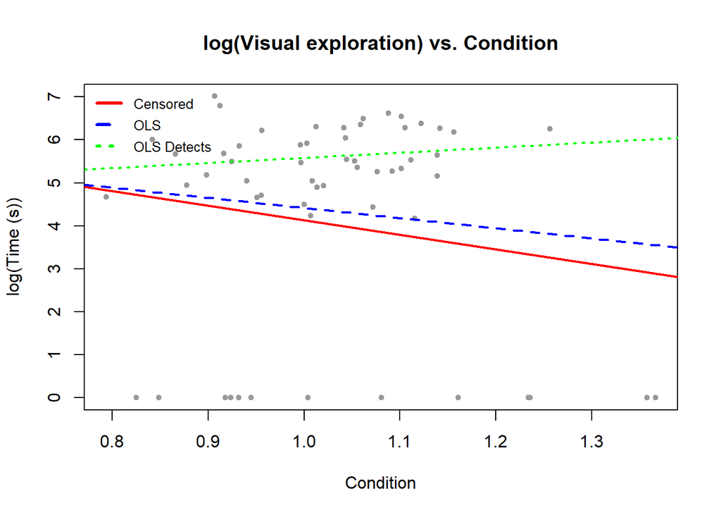

```r
# Plot the results
lineplot <- function() {

  # Add lines
  abline(coef(fit.cen)[1:2], col = "red", lwd = 2)
  abline(coef(fit.OLS), col = "blue", lty = 2, lwd = 2)
  abline(coef(fit.detect), col = "green", lty = 3, lwd = 2)

  # Add legend
  legend(
    "topleft",
    legend = c(
      "Censored",
      "OLS",
      "OLS Detects"
    ),
    lwd = 3 * par("cex"),
    col = c("red", "blue", "green"),
    lty = c(1, 2, 3),
    text.font = 1, bty = "n",
    pt.cex = 1, cex = 0.8, y.intersp = 1.3
  )
}

plot(summary_tracking_complete_no_rep$Condition, (summary_tracking_complete_no_rep$Visual_exp_log), pch = 19, cex = 0.7, col = 'grey60', main = "log(Visual exploration) vs. Condition", xlab = "Condition", ylab = "log(Time (s))")

lineplot()
```

# 8 PERMANOVA + betadisper

This section analyses whether there are differences in the behaviour and use of the snake area. The analyses contain gravid females, but they can be removed if necessary.

## 8.1 Correlation analysis

First we are going to carry out a correlation test between variables to see if we can omit some of them when carrying out the analyses, as they could be highly correlated with each other.

```r
# Select environmental variables
variables_lm <- summary_tracking_complete_no_rep[, c("Distance_Noahs", "Year_invasion", "SVL", "Condition", "Temperature", "R_H")]

# Transform SVL to log
variables_lm$SVL <- log(variables_lm$SVL)

# Correlation results
cor(variables_lm)
```

```
               Distance_Noahs Year_invasion         SVL   Condition Temperature
Distance_Noahs     1.00000000    0.60296767 -0.05239930  0.03031377   0.1617957
Year_invasion      0.60296767    1.00000000 -0.03211695  0.10203083   0.3760371
SVL               -0.05239930   -0.03211695  1.00000000  0.89446469   0.1120937
Condition          0.03031377    0.10203083  0.89446469  1.00000000   0.1712075
Temperature        0.16179573    0.37603711  0.11209374  0.17120754   1.0000000
R_H               -0.19047385   -0.32869555 -0.10046571 -0.17266226  -0.8448673
                      R_H
Distance_Noahs -0.1904739
Year_invasion  -0.3286956
SVL            -0.1004657
Condition      -0.1726623
Temperature    -0.8448673
R_H             1.0000000
```

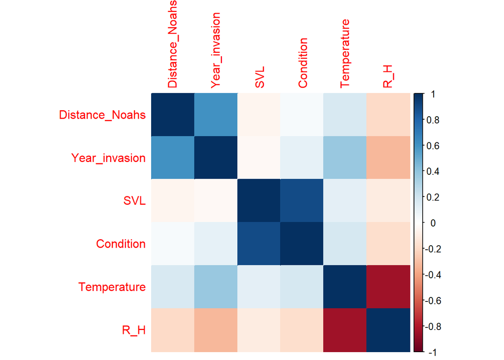

```r
# Correlation plot
corrplot(cor(variables_lm), method="color")
```

Distance to Noah’s garden and year of invasion are highly correlated with each other, as are SVL and condition, or relative humidity and temperature. For the analyses to come, we will use only one of each pair of these correlations to perform the analyses (distance to Noah’s garden, SVL, and temperature), along with the sex variable.

## 8.2 Behaviour analysis

In this section we are going to analyse whether for a given study time (15 min, for example), we observe differences in the type of behaviours expressed by the snakes, depending on different variables (PERMANOVA), and whether the variability of these behaviours is greater or lesser in certain groups (betadisper).

### 8.2.1 Stacked behaviour plot

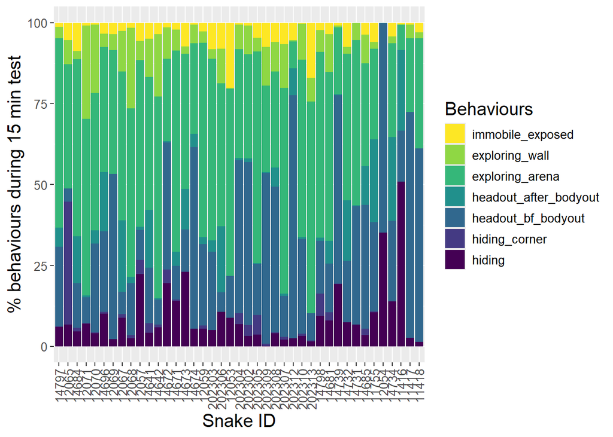

```r
# Delete duplications from the array
# No repeatability filter

# Duplicate data frame
Snake_array_dupl <- Snake_array

# No repeatability filter
snake_id <- names(Snake_array[1,1,])

dupl_positions <- array(data = NA)

# Identify duplicated positions
a <- 1

for (i in 1:length(snake_id)){

  if(duplicated(snake_id)[i] == FALSE){


  } else {

    dupl_positions[a] <- i

    a <- a + 1

  }

}

# Final data frame without duplicates (repeatability)
Snake_array_dupl <- Snake_array_dupl[, , -dupl_positions]

# How much time do we want to analyse
study_time <- 900

# Create data frame
behaviour_df <- as.data.frame(matrix(data = NA, ncol = 15, nrow = length(names(Snake_array_dupl[1,1,]))))

# Column names
colnames(behaviour_df) <- c("Snake_ID", "headout_bf_bodyout", "headout_after_bodyout", "exploring_arena", "exploring_wall", "immobile_exposed", "hiding", "hiding_corner", "year", "distance", "Sex", "SVL", "treatment", "n_eggs", "temperature")

# For all individuals
for (i in 1:length(names(Snake_array_dupl[1,1,]))){

  # If the individual put its head out of the initial refuge 15 min (study time) before the time ended:
  if(summary_tracking_complete_no_rep$Time_head_out_sec_raw[i] + study_time <= 3000){

    # ID individual
    behaviour_df$Snake_ID[i] <- summary_tracking_complete_no_rep$Snake_ID[i]

    # How much time did the snake use doing head-out behaviour(visual exploration) before exiting the initial refuge for the first time
    behaviour_df$headout_bf_bodyout[i] <- sum(Snake_array_dupl[(summary_tracking_complete_no_rep$Time_head_out_sec_raw[i] + 1):min((summary_tracking_complete_no_rep$Time_head_out_sec_raw[i] + study_time), summary_tracking_complete_no_rep$Time_body_out_sec_raw[i]), 22, i] == "head-out")

    # How much time did the snake do head-out in the rest of refuges after exiting for the first time the initial refuge
    behaviour_df$headout_after_bodyout[i] <- sum(Snake_array_dupl[min((summary_tracking_complete_no_rep$Time_body_out_sec_raw[i] + 1),(summary_tracking_complete_no_rep$Time_head_out_sec_raw[i] + study_time + 1)):(summary_tracking_complete_no_rep$Time_head_out_sec_raw[i] + study_time + 1), 22, i] == "head-out")

    # How much time does the snake spend moving around the arena
    behaviour_df$exploring_arena[i] <- sum(Snake_array_dupl[(summary_tracking_complete_no_rep$Time_head_out_sec_raw[i] + 1):(summary_tracking_complete_no_rep$Time_head_out_sec_raw[i] + study_time), 22, i] == "moving")

    # How much time did the snake spend exploring the walls (vertically)
    behaviour_df$exploring_wall[i] <- sum(Snake_array_dupl[(summary_tracking_complete_no_rep$Time_head_out_sec_raw[i] + 1):(summary_tracking_complete_no_rep$Time_head_out_sec_raw[i] + study_time), 22, i] == "exploring wall")

    # How much time did the snake spend inmobile in the midle of the arena
    behaviour_df$immobile_exposed[i] <- sum(Snake_array_dupl[(summary_tracking_complete_no_rep$Time_head_out_sec_raw[i] + 1):(summary_tracking_complete_no_rep$Time_head_out_sec_raw[i] + study_time), 22, i] == "immobile exposed")

    # How much time did the snake hide during trial
    behaviour_df$hiding[i] <- sum(Snake_array_dupl[(summary_tracking_complete_no_rep$Time_head_out_sec_raw[i] + 1):(summary_tracking_complete_no_rep$Time_head_out_sec_raw[i] + study_time), 22, i] == "hidden")

    behaviour_df$hiding_corner[i] <- sum(Snake_array_dupl[(summary_tracking_complete_no_rep$Time_head_out_sec_raw[i] + 1):(summary_tracking_complete_no_rep$Time_head_out_sec_raw[i] + study_time), 22, i] == "hiding / head-out")

    # Other variables
    behaviour_df$year[i] <- summary_tracking_complete_no_rep$Year_invasion[i]

    behaviour_df$distance[i] <- summary_tracking_complete_no_rep$Distance_Noahs[i]

    behaviour_df$Sex[i] <- summary_tracking_complete_no_rep$Sex[i]

    behaviour_df$SVL[i] <- summary_tracking_complete_no_rep$SVL[i]

    behaviour_df$treatment[i] <- summary_tracking_complete_no_rep$Inv_situation[i]

    behaviour_df$n_eggs[i] <- summary_tracking_complete_no_rep$N_eggs[i]

    behaviour_df$temperature[i] <- summary_tracking_complete_no_rep$Temperature[i]


  } else {


  }

}


behaviour_df <- behaviour_df %>% drop_na(Snake_ID)

# Behaviour
# Select columns of interest for stacked behaviour plot
stacked_behaviour <- behaviour_df[, c("Snake_ID", "headout_bf_bodyout", "headout_after_bodyout", "exploring_arena", "exploring_wall", "immobile_exposed", "hiding", "hiding_corner")]

# Snake_ID ordered by year of invasion
snakes_order_by_distance <- behaviour_df[, c("Snake_ID", "distance")]

snakes_order_by_distance <- snakes_order_by_distance[order(snakes_order_by_distance$distance, decreasing = FALSE), ]

# Long format
stacked_behaviour_long <- pivot_longer(stacked_behaviour, cols = c("headout_bf_bodyout", "headout_after_bodyout", "exploring_arena", "exploring_wall", "immobile_exposed", "hiding", "hiding_corner"), names_to = "Behaviour", values_to = "Percentage")

# Percentage of each behaviour
stacked_behaviour_long <- stacked_behaviour_long %>%
  group_by(Snake_ID) %>%
  mutate(Percentage_total = sum(Percentage)) %>%
  ungroup() %>%
  mutate(Percentage = Percentage / Percentage_total * 100)

# Order Snake ID by year of invasion
stacked_behaviour_long$Snake_ID <- factor(stacked_behaviour_long$Snake_ID, levels = snakes_order_by_distance$Snake_ID)

# Order behaviour variables
stacked_behaviour_long$Behaviour <- factor(stacked_behaviour_long$Behaviour, levels = c("immobile_exposed", "exploring_wall", "exploring_arena",  "headout_after_bodyout", "headout_bf_bodyout", "hiding_corner", "hiding"))

# Colors for behaviours
beh_colors <- c(viridis(7)[7], viridis(7)[6], viridis(7)[5], viridis(7)[4], viridis(7)[3], viridis(7)[2], viridis(7)[1])

# Plot
ggplot(stacked_behaviour_long, aes(x = Snake_ID, y = Percentage, fill = Behaviour)) +
  geom_bar(stat = "identity", position = "stack") +
  labs(x = "Snake ID", y = paste("% behaviours during", study_time/60, "min test"), fill = "Behaviours") +
  theme(axis.text.x = element_text(angle = 90, vjust = 0.5, hjust = 1, size = 10),
        legend.text = element_text(size = 10),
        axis.title.x = element_text(size = 15),
        axis.title.y = element_text(size = 15),
        axis.text.y = element_text(size = 10),
        legend.title = element_text(size = 15)) +
  scale_fill_manual(values = beh_colors)
```

### 8.2.2 PERMANOVA

```r
# Alternative data frame with invasion situation
stacked_behaviour_treatment <- behaviour_df

# Delete Snake ID column
stacked_behaviour_complete <- stacked_behaviour_treatment

stacked_behaviour_treatment <- subset(stacked_behaviour_treatment, select = -c(Snake_ID))

# Subset pca columns (numeric)
stacked_behaviour_treatment_var <- stacked_behaviour_treatment[1:7]

# PCA
pca_beh <- prcomp(stacked_behaviour_treatment_var, scale. = T)

# Weights PCA axis
pca_beh$rotation
```

```
                             PC1         PC2         PC3         PC4
headout_bf_bodyout     0.4829386 -0.47346329  0.31745140 -0.01529214
headout_after_bodyout  0.1644386  0.60484679 -0.16154238 -0.29086084
exploring_arena       -0.6067900  0.05165254  0.07060439 -0.10746895
exploring_wall        -0.3667115 -0.30332578 -0.50276967 -0.33830013
immobile_exposed      -0.2788926  0.38166955  0.62425255  0.13981017
hiding                 0.3691774  0.41103487 -0.37490933  0.10040535
hiding_corner         -0.1516105 -0.02640169 -0.29175005  0.87151675
                              PC5         PC6       PC7
headout_bf_bodyout    -0.12946777 -0.04569154 0.6501876
headout_after_bodyout -0.62668010  0.16407951 0.2770818
exploring_arena        0.28908415  0.48404217 0.5428967
exploring_wall        -0.15782305 -0.57819686 0.2169611
immobile_exposed      -0.02433874 -0.58980416 0.1372873
hiding                 0.62326102 -0.23323480 0.3182253
hiding_corner         -0.30493558  0.01069360 0.1963609
```

```r
# Summary
summary(pca_beh)
```

```
Importance of components:
                         PC1    PC2    PC3    PC4     PC5     PC6      PC7
Standard deviation     1.504 1.2464 1.0590 1.0225 0.78490 0.63432 0.001138
Proportion of Variance 0.323 0.2219 0.1602 0.1494 0.08801 0.05748 0.000000
Cumulative Proportion  0.323 0.5449 0.7051 0.8545 0.94252 1.00000 1.000000
```

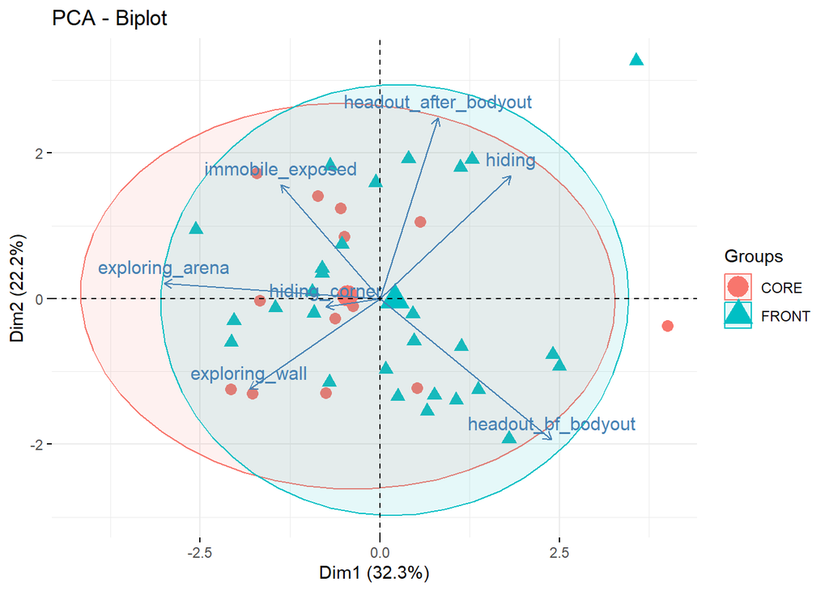

```r
# Plot front vs. core
fviz_pca_biplot(pca_beh, geom.ind = "point",
             habillage = stacked_behaviour_treatment$treatment,
             axes = c(1, 2),
             pointsize = 3,
             addEllipses = TRUE, ellipse.level = 0.9)
```

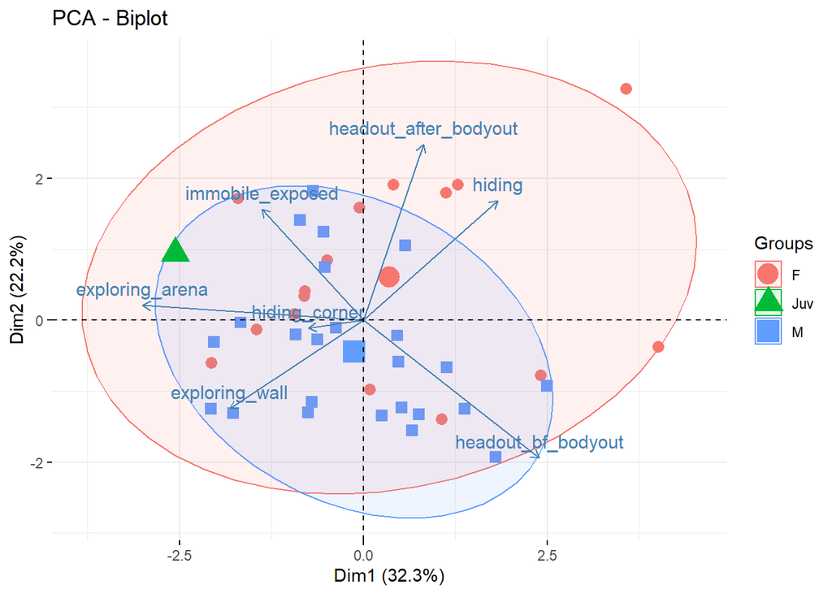

```r
# Plot sex
fviz_pca_biplot(pca_beh, geom.ind = "point",
             habillage = stacked_behaviour_treatment$Sex,
             axes = c(1, 2),
             pointsize = 3,
             addEllipses = TRUE, ellipse.level = 0.9)
```

```r
# PERMANOVA variables
stacked_behaviour_treatment_env <- stacked_behaviour_treatment[, c("treatment", "distance", "SVL", "Sex", "temperature")]

# PERMANOVA without interaction
beh.permanova <- adonis2(stacked_behaviour_treatment_var ~ distance + SVL + Sex + temperature, data = stacked_behaviour_treatment_env, permutations = 999, method="euclidean")

beh.permanova
```

```
Permutation test for adonis under reduced model
Terms added sequentially (first to last)
Permutation: free
Number of permutations: 999

adonis2(formula = stacked_behaviour_treatment_var ~ distance + SVL + Sex + temperature, data = stacked_behaviour_treatment_env, permutations = 999, method = "euclidean")
            Df SumOfSqs      R2      F Pr(>F)
distance     1   364491 0.12009 5.6705  0.004 **
SVL          1    49094 0.01618 0.7638  0.480
Sex          2   339683 0.11192 2.6423  0.033 *
temperature  1    32073 0.01057 0.4990  0.662
Residual    35  2249745 0.74125
Total       40  3035086 1.00000
---
Signif. codes:  0 '***' 0.001 '**' 0.01 '*' 0.05 '.' 0.1 ' ' 1
```

```r
# PERMANOVA with interaction
beh.permanova <- adonis2(stacked_behaviour_treatment_var ~ distance * SVL * Sex * temperature, data = stacked_behaviour_treatment_env, permutations = 999, method="euclidean")

beh.permanova
```

```
Permutation test for adonis under reduced model
Terms added sequentially (first to last)
Permutation: free
Number of permutations: 999

adonis2(formula = stacked_behaviour_treatment_var ~ distance * SVL * Sex * temperature, data = stacked_behaviour_treatment_env, permutations = 999, method = "euclidean")
                             Df SumOfSqs      R2      F Pr(>F)
distance                      1   364491 0.12009 5.8113  0.007 **
SVL                           1    49094 0.01618 0.7827  0.468
Sex                           2   339683 0.11192 2.7079  0.049 *
temperature                   1    32073 0.01057 0.5114  0.647
distance:SVL                  1    66472 0.02190 1.0598  0.331
distance:Sex                  1   149515 0.04926 2.3838  0.080 .
SVL:Sex                       1    43209 0.01424 0.6889  0.516
distance:temperature          1   102750 0.03385 1.6382  0.178
SVL:temperature               1     6434 0.00212 0.1026  0.975
Sex:temperature               1    19727 0.00650 0.3145  0.794
distance:SVL:Sex              1   117902 0.03885 1.8798  0.153
distance:SVL:temperature      1   166589 0.05489 2.6560  0.052 .
distance:Sex:temperature      1     3376 0.00111 0.0538  0.995
SVL:Sex:temperature           1    35731 0.01177 0.5697  0.609
distance:SVL:Sex:temperature  1    32730 0.01078 0.5218  0.640
Residual                     24  1505310 0.49597
Total                        40  3035086 1.00000
---
Signif. codes:  0 '***' 0.001 '**' 0.01 '*' 0.05 '.' 0.1 ' ' 1
```

### 8.2.3 betadisper

```r
# Front vs. core
# Calculate distance matrix
beh.dist <- vegdist(decostand(stacked_behaviour_treatment_var, "norm"), method="euclidean")

beh.dispersion <- betadisper(beh.dist, group = stacked_behaviour_treatment_env$treatment)

permutest(beh.dispersion)
```

```
Permutation test for homogeneity of multivariate dispersions
Permutation: free
Number of permutations: 999

Response: Distances
          Df Sum Sq  Mean Sq      F N.Perm Pr(>F)
Groups     1 0.0145 0.014504 0.3743    999  0.549
Residuals 39 1.5111 0.038747
```

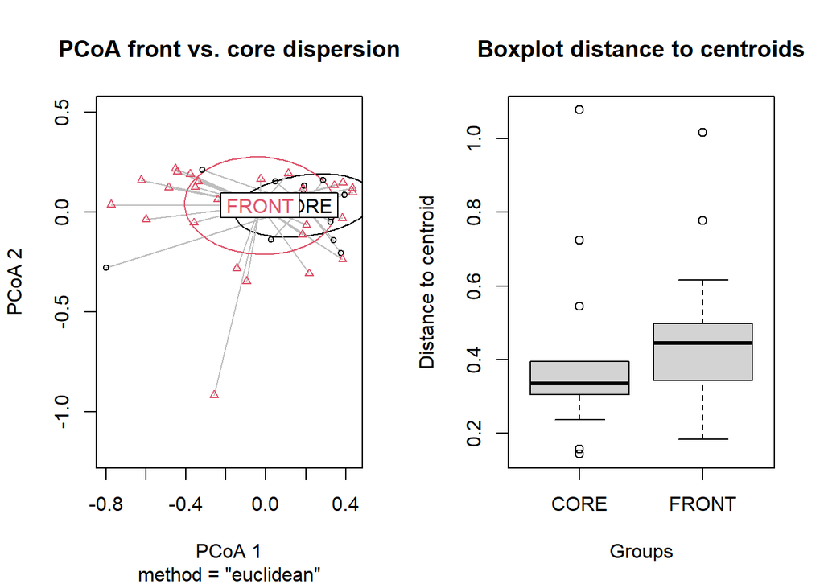

```r
par(mfrow = c(1, 2))

plot(beh.dispersion, hull = FALSE, ellipse = TRUE, main = "PCoA front vs. core dispersion")

boxplot(beh.dispersion, main = "Boxplot distance to centroids", xlab = "Groups")
```

```r
# Sex
# Calculate distance matrix
beh.dist <- vegdist(decostand(stacked_behaviour_treatment_var, "norm"), method="euclidean")

beh.dispersion <- betadisper(beh.dist, group = stacked_behaviour_treatment_env$Sex)

permutest(beh.dispersion)
```

```
Permutation test for homogeneity of multivariate dispersions
Permutation: free
Number of permutations: 999

Response: Distances
          Df  Sum Sq  Mean Sq      F N.Perm Pr(>F)
Groups     2 0.19089 0.095445 2.2134    999   0.13
Residuals 38 1.63858 0.043121
```

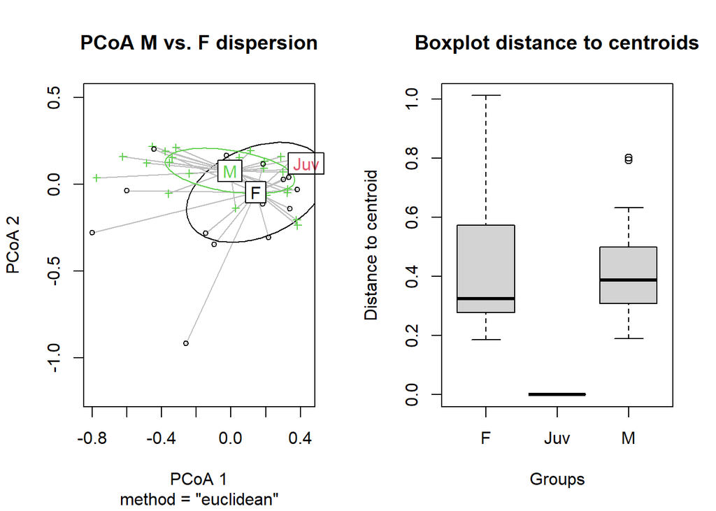

```r
par(mfrow = c(1, 2))

plot(beh.dispersion, hull = FALSE, ellipse = TRUE, main = "PCoA M vs. F dispersion")

boxplot(beh.dispersion, main = "Boxplot distance to centroids", xlab = "Groups")
```

## 8.3 Area use analysis

### 8.3.1 Stacked area use plot

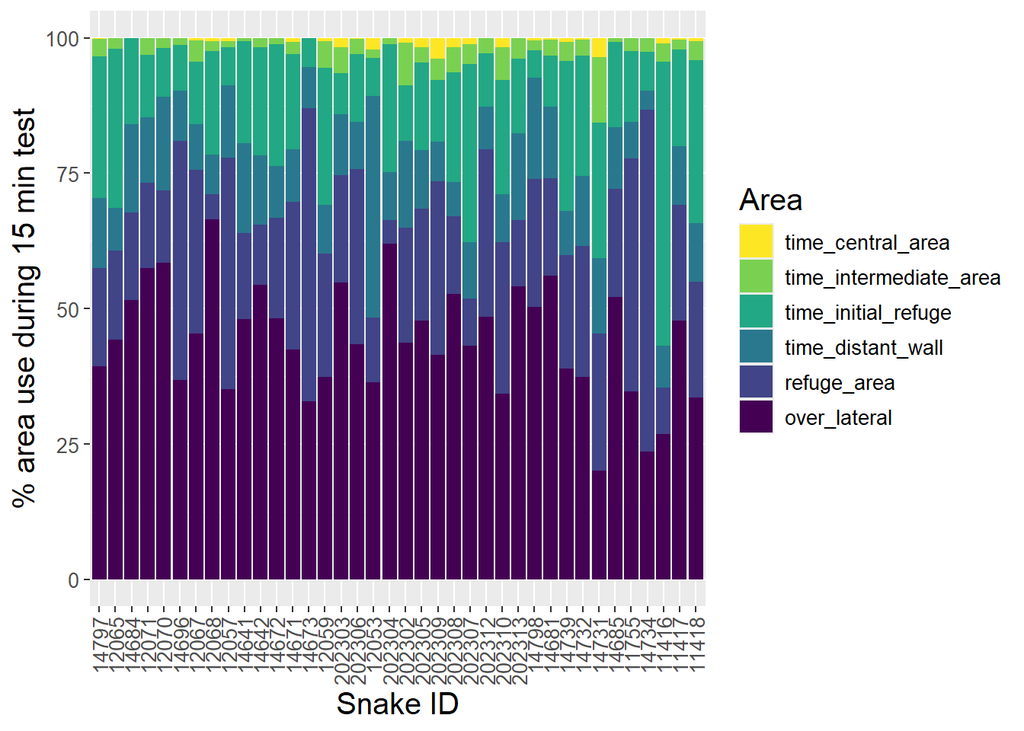

```r
# Duplicate original data frame
Snake_array_dupl <- Snake_array

# No repeatability filter
snake_id <- names(Snake_array[1,1,])

dupl_positions <- array(data = NA)

a <- 1

for (i in 1:length(snake_id)){

  if(duplicated(snake_id)[i] == FALSE){


  } else {

    dupl_positions[a] <- i

    a <- a + 1

  }

}

# Final data frame without duplicates (repeatability)
Snake_array_dupl <- Snake_array_dupl[, , -dupl_positions]

# How much time do we want to analyse
study_time <- 900

# Create data frame
area_df <- as.data.frame(matrix(data = NA, ncol = 16, nrow = length(names(Snake_array_dupl[1,1,]))))

# Column names
colnames(area_df) <- c("Snake_ID", "time_central_area", "time_intermediate_area", "time_refuge_area_1", "time_refuge_area_2", "time_initial_refuge", "time_distant_wall", "time_lateral_1", "time_lateral_2", "year", "distance", "Sex", "SVL", "treatment", "n_eggs", "temperature")

# For all snakes:
for (i in 1:length(names(Snake_array_dupl[1,1,]))){

  # If the snake exited the initial refuge and explored for more than the specified syudy time before time ran out
  if(summary_tracking_complete_no_rep$Time_body_out_sec_raw[i] + study_time <= 3000){

    # Snake ID
    area_df$Snake_ID[i] <- summary_tracking_complete_no_rep$Snake_ID[i]

    # Time spent in each of the areas
    area_df$time_central_area[i] <- sum(as.numeric(Snake_array_dupl[(summary_tracking_complete_no_rep$Time_body_out_sec_raw[i] + 1):(summary_tracking_complete_no_rep$Time_body_out_sec_raw[i] + study_time), 13, i] == "Central area"))

    area_df$time_intermediate_area[i] <- sum(as.numeric(Snake_array_dupl[(summary_tracking_complete_no_rep$Time_body_out_sec_raw[i] + 1):(summary_tracking_complete_no_rep$Time_body_out_sec_raw[i] + study_time), 13, i] == "Intermediate area"))

    area_df$time_refuge_area_1[i] <- sum(as.numeric(Snake_array_dupl[(summary_tracking_complete_no_rep$Time_body_out_sec_raw[i] + 1):(summary_tracking_complete_no_rep$Time_body_out_sec_raw[i] + study_time), 13, i] == "Refuge area 1"))

    area_df$time_refuge_area_2[i] <- sum(as.numeric(Snake_array_dupl[(summary_tracking_complete_no_rep$Time_body_out_sec_raw[i] + 1):(summary_tracking_complete_no_rep$Time_body_out_sec_raw[i] + study_time), 13, i] == "Refuge area 2"))

    area_df$time_initial_refuge[i] <- sum(as.numeric(Snake_array_dupl[(summary_tracking_complete_no_rep$Time_body_out_sec_raw[i] + 1):(summary_tracking_complete_no_rep$Time_body_out_sec_raw[i] + study_time), 13, i] == "Initial refuge"))

    area_df$time_distant_wall[i] <- sum(as.numeric(Snake_array_dupl[(summary_tracking_complete_no_rep$Time_body_out_sec_raw[i] + 1):(summary_tracking_complete_no_rep$Time_body_out_sec_raw[i] + study_time), 13, i] == "Distant wall"))

    area_df$time_lateral_1[i] <- sum(as.numeric(Snake_array_dupl[(summary_tracking_complete_no_rep$Time_body_out_sec_raw[i] + 1):(summary_tracking_complete_no_rep$Time_body_out_sec_raw[i] + study_time), 13, i] == "Lateral 1"))

    area_df$time_lateral_2[i] <- sum(as.numeric(Snake_array_dupl[(summary_tracking_complete_no_rep$Time_body_out_sec_raw[i] + 1):(summary_tracking_complete_no_rep$Time_body_out_sec_raw[i] + study_time), 13, i] == "Lateral 2"))

    # Other variables
    area_df$year[i] <- summary_tracking_complete_no_rep$Year_invasion[i]

    area_df$distance[i] <- summary_tracking_complete_no_rep$Distance_Noahs[i]

    area_df$Sex[i] <- summary_tracking_complete_no_rep$Sex[i]

    area_df$SVL[i] <- summary_tracking_complete_no_rep$SVL[i]

    area_df$treatment[i] <- summary_tracking_complete_no_rep$Inv_situation[i]

    area_df$n_eggs[i] <- summary_tracking_complete_no_rep$N_eggs[i]

    area_df$temperature[i] <- summary_tracking_complete_no_rep$Temperature[i]


  } else {


  }

}


area_df <- area_df %>% drop_na(Snake_ID)


#Select columns
stacked_area <- area_df[, c("Snake_ID", "time_central_area", "time_intermediate_area", "time_refuge_area_1", "time_refuge_area_2", "time_initial_refuge", "time_distant_wall", "time_lateral_1", "time_lateral_2")]

# Snake_ID ordered by distance to Noah's garden
snakes_order_by_distance <- area_df[, c("Snake_ID", "distance")]

snakes_order_by_distance <- snakes_order_by_distance[order(snakes_order_by_distance$distance, decreasing = FALSE), ]

# New variables (merge laterals)
stacked_area$refuge_area <- stacked_area$time_refuge_area_1 + stacked_area$time_refuge_area_2

stacked_area$over_lateral <- stacked_area$time_lateral_1 + stacked_area$time_lateral_2

# We delete these intermediate variables used to calculate previous variables
stacked_area <- subset(stacked_area, select = -c(time_refuge_area_1, time_refuge_area_2, time_lateral_1, time_lateral_2))

# Alternative data frame with invasion situation
stacked_area_treatment <- stacked_area

stacked_area_treatment$treatment <- area_df$treatment

stacked_area_treatment$year <- area_df$year

stacked_area_treatment$SVL <- area_df$SVL

stacked_area_treatment$distance <- area_df$distance

stacked_area_treatment$sex <- area_df$Sex

stacked_area_treatment$temperature <- area_df$temperature

# Long format
stacked_area_long <- pivot_longer(stacked_area, cols = c("time_central_area", "time_intermediate_area", "time_initial_refuge", "time_distant_wall", "refuge_area", "over_lateral"), names_to = "Area", values_to = "Percentage")

# Percentage of each behaviour
stacked_area_long <- stacked_area_long %>%
  group_by(Snake_ID) %>%
  mutate(Percentage_total = sum(Percentage)) %>%
  ungroup() %>%
  mutate(Percentage = Percentage / Percentage_total * 100)

# Order Snake ID by distance to Noah's garden
stacked_area_long$Snake_ID <- factor(stacked_area_long$Snake_ID, levels = snakes_order_by_distance$Snake_ID)

# Order behaviour variables
stacked_area_long$Area <- factor(stacked_area_long$Area, levels = c("time_central_area", "time_intermediate_area", "time_initial_refuge", "time_distant_wall", "refuge_area", "over_lateral"))


# Colors for behaviours
area_colors <- c(viridis(6)[6], viridis(6)[5], viridis(6)[4], viridis(6)[3], viridis(6)[2], viridis(6)[1])

# Plot
ggplot(stacked_area_long, aes(x = Snake_ID, y = Percentage, fill = Area)) +
  geom_bar(stat = "identity", position = "stack") +
  labs(x = "Snake ID", y = paste("% area use during", study_time/60, "min test"), fill = "Area") +
  theme(axis.text.x = element_text(angle = 90, vjust = 0.5, hjust = 1, size = 10),
        legend.text = element_text(size = 10),
        axis.title.x = element_text(size = 15),
        axis.title.y = element_text(size = 15),
        axis.text.y = element_text(size = 10),
        legend.title = element_text(size = 15)) +
  scale_fill_manual(values = area_colors)
```

### 8.3.2 PERMANOVA

```r
# Delete Snake ID column
stacked_area_complete <- stacked_area_treatment

stacked_area_treatment <- subset(stacked_area_treatment, select = -c(Snake_ID))

# Subset pca columns (numeric)
stacked_area_treatment_var <- stacked_area_treatment[, c("time_central_area", "time_intermediate_area", "time_initial_refuge", "time_distant_wall", "refuge_area", "over_lateral")]

# PCA
pca_area <- prcomp(stacked_area_treatment_var, scale. = T)

# Weights PCA axis
pca_area$rotation
```

```
                              PC1        PC2         PC3         PC4
time_central_area      -0.5185508  0.2429416 -0.34613293  0.25182626
time_intermediate_area -0.5718452  0.2144910 -0.10348885  0.36055059
time_initial_refuge    -0.2265918  0.4244870  0.61699727 -0.39048376
time_distant_wall       0.1217155  0.2627736 -0.69544386 -0.56378275
refuge_area            -0.1962962 -0.7434357 -0.05527978  0.00199712
over_lateral            0.5471814  0.3050200 -0.04580838  0.57987434
                               PC5        PC6
time_central_area      -0.69763327 0.04656028
time_intermediate_area  0.68858992 0.11010885
time_initial_refuge    -0.09914015 0.47484207
time_distant_wall       0.16240156 0.29709926
refuge_area            -0.04242041 0.63554058
over_lateral           -0.03390015 0.51773872
```

```r
# Summary
summary(pca_area)
```

```
Importance of components:
                          PC1    PC2    PC3    PC4     PC5       PC6
Standard deviation     1.4110 1.2893 1.1266 0.8557 0.58761 3.432e-16
Proportion of Variance 0.3318 0.2771 0.2115 0.1220 0.05755 0.000e+00
Cumulative Proportion  0.3318 0.6089 0.8204 0.9425 1.00000 1.000e+00
```

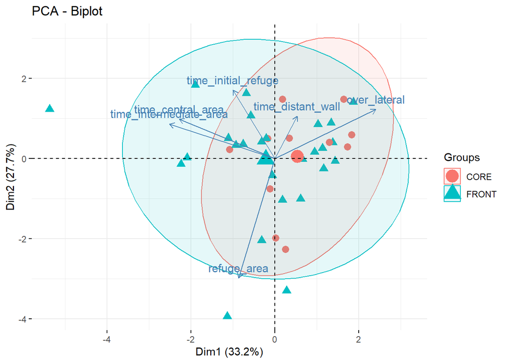

```r
# Plot front vs. core
fviz_pca_biplot(pca_area, geom.ind = "point",
                habillage = stacked_area_treatment$treatment,
                axes = c(1, 2),
                pointsize = 3,
                addEllipses = TRUE, ellipse.level = 0.9)
```

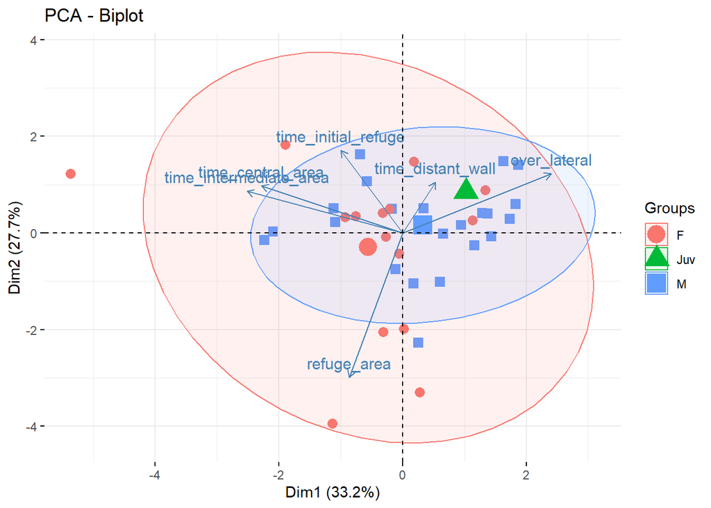

```r
# Plot sex
fviz_pca_biplot(pca_area, geom.ind = "point",
                habillage = stacked_area_treatment$sex,
                axes = c(1, 2),
                pointsize = 3,
                addEllipses = TRUE, ellipse.level = 0.9)
```

```r
# PERMANOVA variables
stacked_area_treatment_env <- stacked_area_treatment[, c("treatment", "distance", "SVL", "sex", "temperature")]

# PERMANOVA without interaction
beh.area <- adonis2(stacked_area_treatment_var ~ distance + SVL + sex + temperature, data = stacked_area_treatment_env, permutations = 999, method="euclidean")

beh.area
```

```
Permutation test for adonis under reduced model
Terms added sequentially (first to last)
Permutation: free
Number of permutations: 999

adonis2(formula = stacked_area_treatment_var ~ distance + SVL + sex + temperature, data = stacked_area_treatment_env, permutations = 999, method = "euclidean")
            Df SumOfSqs      R2      F Pr(>F)
distance     1    43893 0.03592 1.3876  0.282
SVL          1    14645 0.01198 0.4630  0.678
sex          2   110387 0.09032 1.7448  0.146
temperature  1    40961 0.03352 1.2949  0.286
Residual    32  1012228 0.82826
Total       37  1222113 1.00000
```

```r
# PERMANOVA with interaction
beh.area <- adonis2(stacked_area_treatment_var ~ distance * SVL * sex * temperature, data = stacked_area_treatment_env, permutations = 999, method="euclidean")

beh.area
```

```
Permutation test for adonis under reduced model
Terms added sequentially (first to last)
Permutation: free
Number of permutations: 999

adonis2(formula = stacked_area_treatment_var ~ distance * SVL * sex * temperature, data = stacked_area_treatment_env, permutations = 999, method = "euclidean")
                             Df SumOfSqs      R2      F Pr(>F)
distance                      1    43893 0.03592 1.5683  0.242
SVL                           1    14645 0.01198 0.5233  0.657
sex                           2   110387 0.09032 1.9721  0.105
temperature                   1    40961 0.03352 1.4636  0.244
distance:SVL                  1    45889 0.03755 1.6397  0.209
distance:sex                  1    49491 0.04050 1.7684  0.183
SVL:sex                       1    55737 0.04561 1.9915  0.144
distance:temperature          1    18641 0.01525 0.6661  0.563
SVL:temperature               1    46281 0.03787 1.6537  0.195
sex:temperature               1    48664 0.03982 1.7388  0.177
distance:SVL:sex              1    30309 0.02480 1.0830  0.356
distance:SVL:temperature      1    34548 0.02827 1.2344  0.273
distance:sex:temperature      1    36275 0.02968 1.2961  0.290
SVL:sex:temperature           1    47671 0.03901 1.7034  0.183
distance:SVL:sex:temperature  1    10998 0.00900 0.3930  0.710
Residual                     21   587723 0.48091
Total                        37  1222113 1.00000
```

### 8.3.3 betadisper

```r
# Front vs. core
# Calculate distance matrix
area.dist <- vegdist(decostand(stacked_area_treatment_var, "norm"), method="euclidean")

area.dispersion <- betadisper(area.dist, group = stacked_area_treatment_env$treatment)

permutest(area.dispersion)
```

```
Permutation test for homogeneity of multivariate dispersions
Permutation: free
Number of permutations: 999

Response: Distances
          Df  Sum Sq  Mean Sq      F N.Perm Pr(>F)
Groups     1 0.00474 0.004744 0.1547    999  0.719
Residuals 36 1.10383 0.030662
```

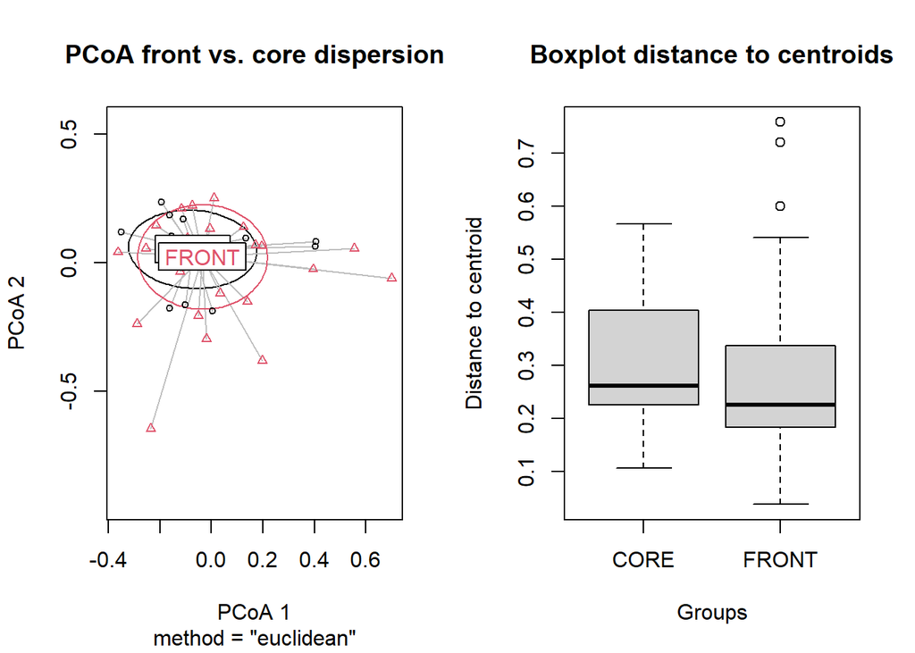

```r
par(mfrow = c(1, 2))

plot(area.dispersion, hull = FALSE, ellipse = TRUE, main = "PCoA front vs. core dispersion")

boxplot(area.dispersion, main = "Boxplot distance to centroids", xlab = "Groups")
```

```r
# Sex
# Calculate distance matrix
area.dist <- vegdist(decostand(stacked_area_treatment_var, "norm"), method="euclidean")

area.dispersion <- betadisper(area.dist, group = stacked_area_treatment_env$sex)

permutest(area.dispersion)
```

```
Permutation test for homogeneity of multivariate dispersions
Permutation: free
Number of permutations: 999

Response: Distances
          Df  Sum Sq  Mean Sq      F N.Perm Pr(>F)
Groups     2 0.24387 0.121935 5.7611    999  0.005 **
Residuals 35 0.74079 0.021165
---
Signif. codes:  0 '***' 0.001 '**' 0.01 '*' 0.05 '.' 0.1 ' ' 1
```

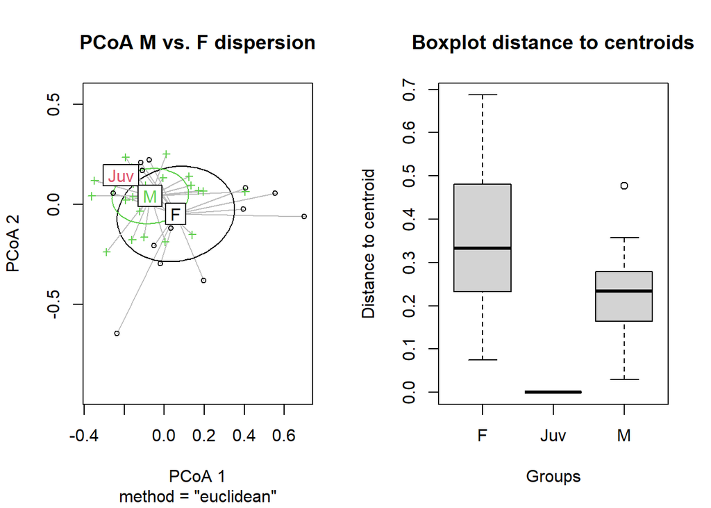

```r
par(mfrow = c(1, 2))

plot(area.dispersion, hull = FALSE, ellipse = TRUE, main = "PCoA M vs. F dispersion")

boxplot(area.dispersion, main = "Boxplot distance to centroids", xlab = "Groups")
```

# 9 Cumulative exploration tests

In this section we will analyse whether there are differences between groups (FRONT vs. CORE and M vs. F) in terms of the behaviour expressed during a certain exploration time (i. e. 15 min). The variables we will look at are the average speed of the individuals, the total distance travelled (in total, including vertical, and only while exploring), the total time exploring, the total time hidden, the number of visits to refuges, the average time the snake has been hidden in these refuges, and the average time the snake is exposed between visits to refuges.

These results include pregnant females. It could be done without pregnant females as well. These results are also exclusive to a specific time range (15 min in this case), but the total time to be analysed could be modified.

## 9.1 Data filtering and shared functions

```r
# Duplicate data frame
Snake_array_dupl <- Snake_array

# No repeatability filter
snake_id <- names(Snake_array[1,1,])

dupl_positions <- array(data = NA)

a <- 1

for (i in 1:length(snake_id)){

  if(duplicated(snake_id)[i] == FALSE){


  } else {

    dupl_positions[a] <- i

    a <- a + 1

  }

}

# Final data frame without duplicates (repeatability)
Snake_array_dupl <- Snake_array_dupl[, , -dupl_positions]

# How much time do we want to analyse
study_time <- 900

# Create data frame
movement_df <- as.data.frame(matrix(data = NA, ncol = 18, nrow = length(names(Snake_array_dupl[1,1,]))))

# Column names
colnames(movement_df) <- c("Snake_ID", "avg_speed", "total_dist_trav", "avg_speed_moving", "total_dist_trav_moving", "time_moving", "time_hidden", "n_visits_refuge", "avg_time_hidden", "avg_time_bw_refuges", "year", "distance", "Sex", "SVL", "Condition", "treatment", "n_eggs", "temperature")

for (i in 1:length(names(Snake_array_dupl[1,1,]))){

  # body-out better than head-out
  if(summary_tracking_complete_no_rep$Time_body_out_sec_raw[i] + study_time <= 3000){

    # snake ID
    movement_df$Snake_ID[i] <- summary_tracking_complete_no_rep$Snake_ID[i]

    # avg speed during the tested time, independent of behaviour
    movement_df$avg_speed[i] <- mean(as.numeric(Snake_array_dupl[(summary_tracking_complete_no_rep$Time_body_out_sec_raw[i] + 1):(summary_tracking_complete_no_rep$Time_body_out_sec_raw[i] + study_time), 21, i]))

    # total distance travelled, independent of behaviour
    movement_df$total_dist_trav[i] <- sum(as.numeric(Snake_array_dupl[(summary_tracking_complete_no_rep$Time_body_out_sec_raw[i] + 1):(summary_tracking_complete_no_rep$Time_body_out_sec_raw[i] + study_time), 21, i]))


    # subsample: extract only rows when snake is moving

    movement_df_moving <- as.data.frame(Snake_array_dupl[(summary_tracking_complete_no_rep$Time_body_out_sec_raw[i] + 1):(summary_tracking_complete_no_rep$Time_body_out_sec_raw[i] + study_time), , i])

    movement_df_moving <- subset(movement_df_moving, behaviour == "moving", select = t:behaviour)

    movement_df$avg_speed_moving[i] <- mean(as.numeric(movement_df_moving[, 21]))

    movement_df$total_dist_trav_moving[i] <- sum(as.numeric(movement_df_moving[, 21]))

    movement_df$time_moving[i] <- sum(movement_df_moving[, 22] == "moving")

    # subsample: extract only rows when snake is hidden

    movement_df_hidden <- as.data.frame(Snake_array_dupl[(summary_tracking_complete_no_rep$Time_body_out_sec_raw[i] + 1):(summary_tracking_complete_no_rep$Time_body_out_sec_raw[i] + study_time), , i])

    movement_df_hidden <- subset(movement_df_hidden, behaviour == "hidden", select = t:behaviour)

    movement_df$time_hidden[i] <- sum(movement_df_hidden[, 22] == "hidden")

    # differences between numbers
    diff_hidden <- diff(as.numeric(movement_df_hidden$t))

    jumps <- diff_hidden[diff_hidden > 1]

    n_jumps <- length(jumps)

    jump_index <- which(diff_hidden > 1)

    chunk <- split(as.numeric(movement_df_hidden$t), cumsum(c(1, diff_hidden > 1)))

    chunk_length <- sapply(chunk, length)

    # jump demonstrates a change from hide 1 to hide 2

    # We are going to select only those visits that last for longer than 5 seconds, as visits that last for less than 5 seconds, it's just exploration. The snake doesn't hide completely, it only enters its head and exits in a moment
    valid_visits <- chunk_length > 5

    n_jumps_valid <- sum(valid_visits) - 1

    movement_df$n_visits_refuge[i] <- n_jumps + 1

    movement_df$avg_time_bw_refuges[i] <- mean(jumps[valid_visits[-length(valid_visits)]])

    movement_df$avg_time_hidden[i] <- mean(chunk_length[valid_visits])

    movement_df$year[i] <- summary_tracking_complete_no_rep$Year_invasion[i]

    movement_df$distance[i] <- summary_tracking_complete_no_rep$Distance_Noahs[i]

    movement_df$Sex[i] <- summary_tracking_complete_no_rep$Sex[i]

    movement_df$SVL[i] <- summary_tracking_complete_no_rep$SVL[i]

    movement_df$Condition[i] <- summary_tracking_complete_no_rep$Condition[i]

    movement_df$treatment[i] <- summary_tracking_complete_no_rep$Inv_situation[i]

    movement_df$n_eggs[i] <- summary_tracking_complete_no_rep$N_eggs[i]

    movement_df$temperature[i] <- summary_tracking_complete_no_rep$Temperature[i]


  } else {


  }

}


movement_df <- movement_df %>% drop_na(Snake_ID)

# We delete juveniles, as for the paired comparisons, you need exactly 2 factors
movement_df <- movement_df[which(movement_df$Sex != "Juv"),]

# t-tests
# Function to compare different exploratory variables depending on front vs. core
compare_core_front <- function(variable) {
  t.test(movement_df[[variable]] ~ movement_df$treatment)
}

# Function to compare different exploratory variables depending on male vs. female
compare_sex <- function(variable) {
  t.test(movement_df[[variable]] ~ movement_df$Sex)
}

# To check normality and homoscedasticity
verify_norm <- function(variable, group) {
  shapiro.test(movement_df[[variable]])
  leveneTest(movement_df[[variable]] ~ movement_df[[group]])
}

# Plots
# Boxplot 'core' vs 'front'
boxplot_core_front <- function(variable) {
  ggplot(movement_df, aes(x = treatment, y = .data[[variable]], fill = treatment)) +
    geom_boxplot() +
    labs(title = "Boxplots",
         x = "Group", y = variable) +
    theme_minimal()
}

# Boxplot M vs. F
boxplot_sex <- function(variable) {
  ggplot(movement_df, aes(x = Sex, y = .data[[variable]], fill = Sex)) +
    geom_boxplot() +
    labs(title = "",
         x = "Sex", y = variable) +
    theme_minimal()
}

# Scatterplot 'distance'
scatterplot_distance <- function(variable) {
  ggplot(movement_df, aes(x = distance, y = .data[[variable]])) +
    geom_point() +
    geom_smooth(method = "lm", se = FALSE, color = "blue") +
    labs(title = "Scatterplots",
         x = "Distance to Noah's garden", y = variable) +
    theme_minimal()
}

# Scatterplot 'year'
scatterplot_year <- function(variable) {
  ggplot(movement_df, aes(x = year, y = .data[[variable]])) +
    geom_point() +
    geom_smooth(method = "lm", se = FALSE, color = "blue") +
    labs(title = "",
         x = "Year", y = variable) +
    theme_minimal()
}

# Scatterplot 'condition'
scatterplot_condition <- function(variable) {
  ggplot(movement_df, aes(x = Condition, y = .data[[variable]])) +
    geom_point() +
    geom_smooth(method = "lm", se = FALSE, color = "blue") +
    labs(title = "",
         x = "Condition", y = variable) +
    theme_minimal()
}

combine_plots <- function(variable) {
  # Crear los cinco gráficos utilizando las funciones existentes
  plot1 <- boxplot_core_front(variable)
  plot2 <- boxplot_sex(variable)
  plot3 <- scatterplot_distance(variable)
  plot4 <- scatterplot_year(variable)
  plot5 <- scatterplot_condition(variable)

  # Combinar los gráficos en una única figura
  combined_plot <- (plot1 | plot2) / (plot3 | plot4 | plot5)

  # Mostrar el gráfico combinado
  combined_plot
}
```

## 9.2 Paired t-tests + boxplots + linear regressions

### 9.2.1 Average speed while exploring

```r
# t-test + normality & homoscedasticity check
# Select variables to compare
variables <- c("avg_speed_moving")

# Front vs. core
results_core_front <- lapply(variables, compare_core_front)
names(results_core_front) <- variables

# Males vs. females
results_sex <- lapply(variables, compare_sex)
names(results_sex) <- variables

# Verify normality and homoscedasticity
verify_core_front <- lapply(variables, verify_norm, group = "treatment")
verify_sex <- lapply(variables, verify_norm, group = "Sex")

# Print results
results_core_front
```

```
$avg_speed_moving

    Welch Two Sample t-test

data:  movement_df[[variable]] by movement_df$treatment
t = -1.042, df = 16.147, p-value = 0.3128
alternative hypothesis: true difference in means between group CORE and group FRONT is not equal to 0
95 percent confidence interval:
 -0.02564877  0.00873517
sample estimates:
 mean in group CORE mean in group FRONT
         0.09237024          0.10082704
```

```r
results_sex
```

```
$avg_speed_moving

    Welch Two Sample t-test

data:  movement_df[[variable]] by movement_df$Sex
t = -2.2866, df = 29.86, p-value = 0.02949
alternative hypothesis: true difference in means between group F and group M is not equal to 0
95 percent confidence interval:
 -0.028854209 -0.001625485
sample estimates:
mean in group F mean in group M
     0.08925133      0.10449118
```

```r
verify_core_front
```

```
[[1]]
Levene's Test for Homogeneity of Variance (center = median)
      Df F value Pr(>F)
group  1  0.1212 0.7298
      35
```

```r
verify_sex
```

```
[[1]]
Levene's Test for Homogeneity of Variance (center = median)
      Df F value Pr(>F)
group  1  0.0016 0.9681
      35
```

```r
# lm
model_distance <- lm(avg_speed_moving ~ distance + Condition + Sex + temperature, data = movement_df)
summary(model_distance)
```

```
Call:
lm(formula = avg_speed_moving ~ distance + Condition + Sex +
    temperature, data = movement_df)

Residuals:
      Min        1Q    Median        3Q       Max
-0.033713 -0.008278  0.000310  0.008282  0.027440

Coefficients:
              Estimate Std. Error t value Pr(>|t|)
(Intercept) -1.074e-01  3.255e-02  -3.300  0.00238 **
distance     3.095e-07  1.038e-06   0.298  0.76742
Condition    1.381e-01  3.106e-02   4.448  9.8e-05 ***
SexM         1.168e-02  5.440e-03   2.148  0.03943 *
temperature  1.938e-03  7.967e-04   2.433  0.02074 *
---
Signif. codes:  0 '***' 0.001 '**' 0.01 '*' 0.05 '.' 0.1 ' ' 1

Residual standard error: 0.01399 on 32 degrees of freedom
Multiple R-squared:  0.6046,    Adjusted R-squared:  0.5551
F-statistic: 12.23 on 4 and 32 DF,  p-value: 3.816e-06
```

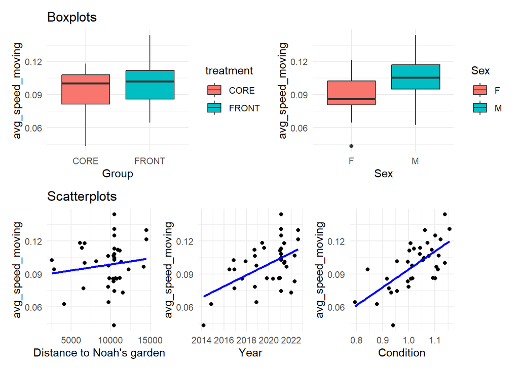

```r
# Plots
combine_plots(variables)
```

### 9.2.2 Total distance traveled while exploring

```r
# t-test + normality & homoscedasticity check
# Select variables to compare
variables <- c("total_dist_trav_moving")

# Front vs. core
results_core_front <- lapply(variables, compare_core_front)
names(results_core_front) <- variables

# Males vs. females
results_sex <- lapply(variables, compare_sex)
names(results_sex) <- variables

# Verify normality and homoscedasticity
verify_core_front <- lapply(variables, verify_norm, group = "treatment")
verify_sex <- lapply(variables, verify_norm, group = "Sex")

# Print results
results_core_front
```

```
$total_dist_trav_moving

    Welch Two Sample t-test

data:  movement_df[[variable]] by movement_df$treatment
t = -0.98434, df = 25.351, p-value = 0.3342
alternative hypothesis: true difference in means between group CORE and group FRONT is not equal to 0
95 percent confidence interval:
 -17.029926   6.010272
sample estimates:
 mean in group CORE mean in group FRONT
           49.70076            55.21059
```

```r
results_sex
```

```
$total_dist_trav_moving

    Welch Two Sample t-test

data:  movement_df[[variable]] by movement_df$Sex
t = -0.87692, df = 23.848, p-value = 0.3893
alternative hypothesis: true difference in means between group F and group M is not equal to 0
95 percent confidence interval:
 -18.360687   7.413347
sample estimates:
mean in group F mean in group M
       50.31792        55.79158
```

```r
verify_core_front
```

```
[[1]]
Levene's Test for Homogeneity of Variance (center = median)
      Df F value Pr(>F)
group  1  0.9556  0.335
      35
```

```r
verify_sex
```

```
[[1]]
Levene's Test for Homogeneity of Variance (center = median)
      Df F value Pr(>F)
group  1  1.2323 0.2745
      35
```

```r
# lm
model_distance <- lm(total_dist_trav_moving ~ distance + Condition + Sex + temperature, data = movement_df)
summary(model_distance)
```

```
Call:
lm(formula = total_dist_trav_moving ~ distance + Condition +
    Sex + temperature, data = movement_df)

Residuals:
    Min      1Q  Median      3Q     Max
-27.903 -12.182  -2.492  11.660  29.267

Coefficients:
              Estimate Std. Error t value Pr(>|t|)
(Intercept) -5.848e+01  3.790e+01  -1.543   0.1327
distance     3.057e-04  1.208e-03   0.253   0.8018
Condition    6.506e+01  3.616e+01   1.799   0.0814 .
SexM         3.676e+00  6.334e+00   0.580   0.5657
temperature  1.439e+00  9.276e-01   1.552   0.1306
---
Signif. codes:  0 '***' 0.001 '**' 0.01 '*' 0.05 '.' 0.1 ' ' 1

Residual standard error: 16.29 on 32 degrees of freedom
Multiple R-squared:  0.2316,    Adjusted R-squared:  0.1356
F-statistic: 2.411 on 4 and 32 DF,  p-value: 0.06949
```

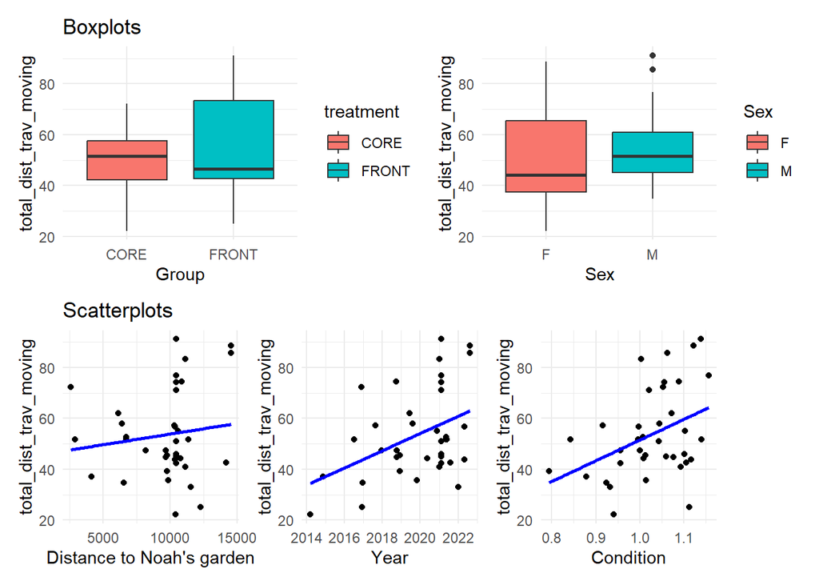

```r
# Plots
combine_plots(variables)
```

### 9.2.3 Number of refuge visits

```r
# t-test + normality & homoscedasticity check
# Select variables to compare
variables <- c("n_visits_refuge")

# Front vs. core
results_core_front <- lapply(variables, compare_core_front)
names(results_core_front) <- variables

# Males vs. females
results_sex <- lapply(variables, compare_sex)
names(results_sex) <- variables

# Verify normality and homoscedasticity
verify_core_front <- lapply(variables, verify_norm, group = "treatment")
verify_sex <- lapply(variables, verify_norm, group = "Sex")

# Print results
results_core_front
```

```
$n_visits_refuge

    Welch Two Sample t-test

data:  movement_df[[variable]] by movement_df$treatment
t = -1.7375, df = 16.595, p-value = 0.1008
alternative hypothesis: true difference in means between group CORE and group FRONT is not equal to 0
95 percent confidence interval:
 -3.1078194  0.3036236
sample estimates:
 mean in group CORE mean in group FRONT
           4.636364            6.038462
```

```r
results_sex
```

```
$n_visits_refuge

    Welch Two Sample t-test

data:  movement_df[[variable]] by movement_df$Sex
t = 1.9574, df = 26.194, p-value = 0.06104
alternative hypothesis: true difference in means between group F and group M is not equal to 0
95 percent confidence interval:
 -0.07074495  2.91316919
sample estimates:
mean in group F mean in group M
       6.466667        5.045455
```

```r
verify_core_front
```

```
[[1]]
Levene's Test for Homogeneity of Variance (center = median)
      Df F value Pr(>F)
group  1  0.2813 0.5992
      35
```

```r
verify_sex
```

```
[[1]]
Levene's Test for Homogeneity of Variance (center = median)
      Df F value Pr(>F)
group  1  0.1337 0.7168
      35
```

```r
# lm
model_distance <- lm(n_visits_refuge ~ distance + Condition + Sex + temperature, data = movement_df)
summary(model_distance)
```

```
Call:
lm(formula = n_visits_refuge ~ distance + Condition + Sex + temperature,
    data = movement_df)

Residuals:
    Min      1Q  Median      3Q     Max
-5.0183 -1.1698 -0.0217  0.9987  3.3444

Coefficients:
              Estimate Std. Error t value Pr(>|t|)
(Intercept) -1.863e+00  4.828e+00  -0.386   0.7021
distance    -5.163e-05  1.539e-04  -0.335   0.7395
Condition    4.216e+00  4.607e+00   0.915   0.3670
SexM        -1.772e+00  8.069e-01  -2.195   0.0355 *
temperature  1.688e-01  1.182e-01   1.428   0.1629
---
Signif. codes:  0 '***' 0.001 '**' 0.01 '*' 0.05 '.' 0.1 ' ' 1

Residual standard error: 2.075 on 32 degrees of freedom
Multiple R-squared:  0.1926,    Adjusted R-squared:  0.09168
F-statistic: 1.908 on 4 and 32 DF,  p-value: 0.1331
```

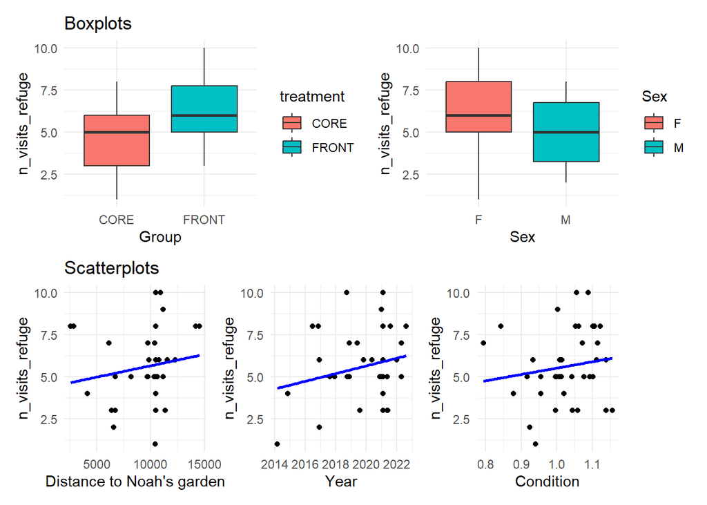

```r
# Plots
combine_plots(variables)
```

### 9.2.4 Average time hiding

```r
# t-test + normality & homoscedasticity check
# Select variables to compare
variables <- c("avg_time_hidden")

# Front vs. core
results_core_front <- lapply(variables, compare_core_front)
names(results_core_front) <- variables

# Males vs. females
results_sex <- lapply(variables, compare_sex)
names(results_sex) <- variables

# Verify normality and homoscedasticity
verify_core_front <- lapply(variables, verify_norm, group = "treatment")
verify_sex <- lapply(variables, verify_norm, group = "Sex")

# Print results
results_core_front
```

```
$avg_time_hidden

    Welch Two Sample t-test

data:  movement_df[[variable]] by movement_df$treatment
t = 1.1601, df = 13.039, p-value = 0.2668
alternative hypothesis: true difference in means between group CORE and group FRONT is not equal to 0
95 percent confidence interval:
 -8.066321 26.788932
sample estimates:
 mean in group CORE mean in group FRONT
           30.84848            21.48718
```

```r
results_sex
```

```
$avg_time_hidden

    Welch Two Sample t-test

data:  movement_df[[variable]] by movement_df$Sex
t = 1.5272, df = 18.123, p-value = 0.144
alternative hypothesis: true difference in means between group F and group M is not equal to 0
95 percent confidence interval:
 -3.924404 24.852788
sample estimates:
mean in group F mean in group M
       30.49222        20.02803
```

```r
verify_core_front
```

```
[[1]]
Levene's Test for Homogeneity of Variance (center = median)
      Df F value Pr(>F)
group  1  2.4107 0.1295
      35
```

```r
verify_sex
```

```
[[1]]
Levene's Test for Homogeneity of Variance (center = median)
      Df F value  Pr(>F)
group  1  3.9949 0.05345 .
      35
---
Signif. codes:  0 '***' 0.001 '**' 0.01 '*' 0.05 '.' 0.1 ' ' 1
```

```r
# lm
model_distance <- lm(avg_time_hidden ~ distance + Condition + Sex + temperature, data = movement_df)
summary(model_distance)
```

```
Call:
lm(formula = avg_time_hidden ~ distance + Condition + Sex + temperature,
    data = movement_df)

Residuals:
    Min      1Q  Median      3Q     Max
-21.894 -12.788  -2.632   5.615  41.634

Coefficients:
              Estimate Std. Error t value Pr(>|t|)
(Intercept)  1.194e+02  4.066e+01   2.935  0.00613 **
distance     1.236e-04  1.296e-03   0.095  0.92463
Condition   -4.522e+01  3.880e+01  -1.166  0.25241
SexM        -7.870e+00  6.796e+00  -1.158  0.25545
temperature -1.619e+00  9.953e-01  -1.627  0.11357
---
Signif. codes:  0 '***' 0.001 '**' 0.01 '*' 0.05 '.' 0.1 ' ' 1

Residual standard error: 17.48 on 32 degrees of freedom
Multiple R-squared:  0.2078,    Adjusted R-squared:  0.1088
F-statistic: 2.099 on 4 and 32 DF,  p-value: 0.104
```

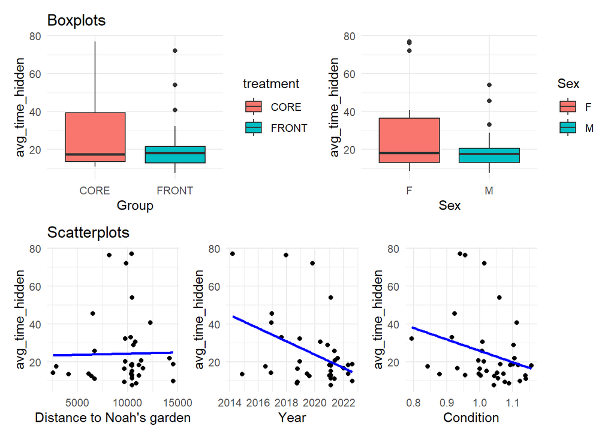

```r
# Plots
combine_plots(variables)
```

### 9.2.5 Average time between refuge visits

```r
# t-test + normality & homoscedasticity check
# Select variables to compare
variables <- c("avg_time_bw_refuges")

# Front vs. core
results_core_front <- lapply(variables, compare_core_front)
names(results_core_front) <- variables

# Males vs. females
results_sex <- lapply(variables, compare_sex)
names(results_sex) <- variables

# Verify normality and homoscedasticity
verify_core_front <- lapply(variables, verify_norm, group = "treatment")
verify_sex <- lapply(variables, verify_norm, group = "Sex")

# Print results
results_core_front
```

```
$avg_time_bw_refuges

    Welch Two Sample t-test

data:  movement_df[[variable]] by movement_df$treatment
t = 1.2161, df = 17.321, p-value = 0.2403
alternative hypothesis: true difference in means between group CORE and group FRONT is not equal to 0
95 percent confidence interval:
 -18.36256  68.49923
sample estimates:
 mean in group CORE mean in group FRONT
           141.3767            116.3083
```

```r
results_sex
```

```
$avg_time_bw_refuges

    Welch Two Sample t-test

data:  movement_df[[variable]] by movement_df$Sex
t = -1.0522, df = 33.765, p-value = 0.3002
alternative hypothesis: true difference in means between group F and group M is not equal to 0
95 percent confidence interval:
 -55.61414  17.67669
sample estimates:
mean in group F mean in group M
       111.6798        130.6485
```

```r
verify_core_front
```

```
[[1]]
Levene's Test for Homogeneity of Variance (center = median)
      Df F value Pr(>F)
group  1  0.4426 0.5104
      34
```

```r
verify_sex
```

```
[[1]]
Levene's Test for Homogeneity of Variance (center = median)
      Df F value Pr(>F)
group  1  2.2173 0.1457
      34
```

```r
# lm
model_distance <- lm(avg_time_bw_refuges ~ distance + Condition + Sex + temperature, data = movement_df)
summary(model_distance)
```

```
Call:
lm(formula = avg_time_bw_refuges ~ distance + Condition + Sex +
    temperature, data = movement_df)

Residuals:
     Min       1Q   Median       3Q      Max
-111.803  -35.028   -9.471   37.225  112.966

Coefficients:
              Estimate Std. Error t value Pr(>|t|)
(Intercept) 132.136070 140.324486   0.942    0.354
distance     -0.002935   0.004406  -0.666    0.510
Condition   -12.359148 133.191952  -0.093    0.927
SexM         11.507480  23.340636   0.493    0.625
temperature   0.896479   3.383519   0.265    0.793

Residual standard error: 59.39 on 31 degrees of freedom
  (1 observation deleted due to missingness)
Multiple R-squared:  0.04697,   Adjusted R-squared:  -0.076
F-statistic: 0.3819 on 4 and 31 DF,  p-value: 0.8198
```

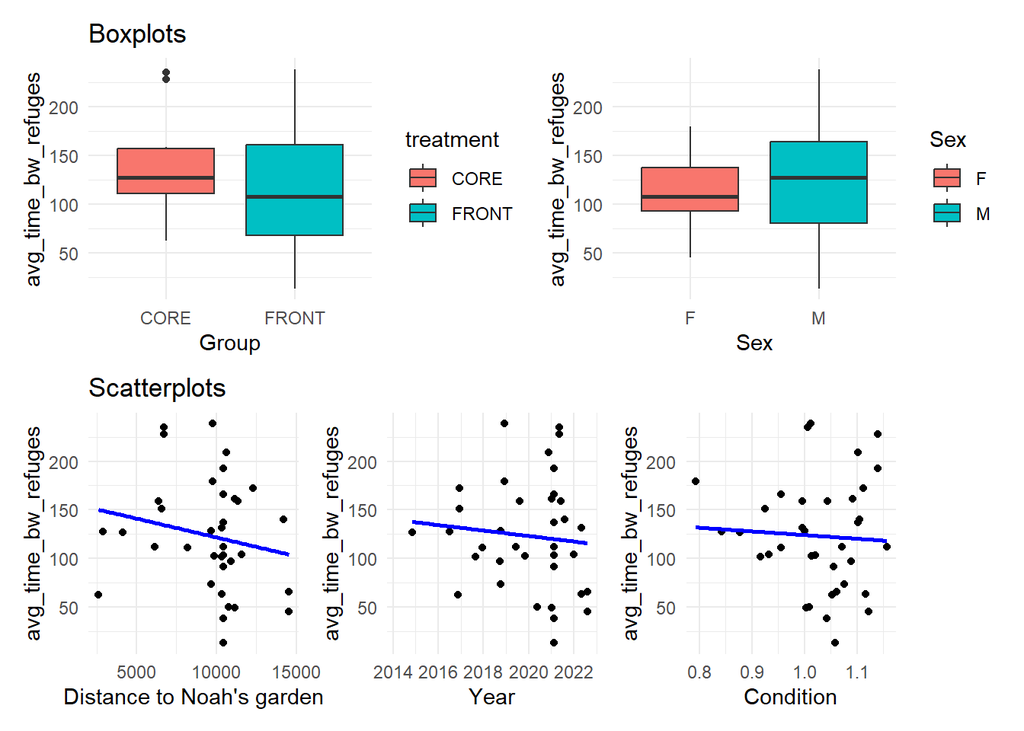

```r
# Plots
combine_plots(variables)
```